# Behavior of Youtube Ads and the user

## How does Youtube personalize their ways of showing ads to me?

[figure not shown]

Image of person opening Youtube on their phone and on their TV in the background

I had tracked the type of ads that I received on Youtube, the length of the ads, their relevancy to me and what time of the day I had received them.

## Does time of day affect the length of the ad?

Ads that appear relatively earlier in the day are more likely to be short. Entertainment ads appear more frequently in earlier times of the day while services and self improvement ads appear more in the evening.

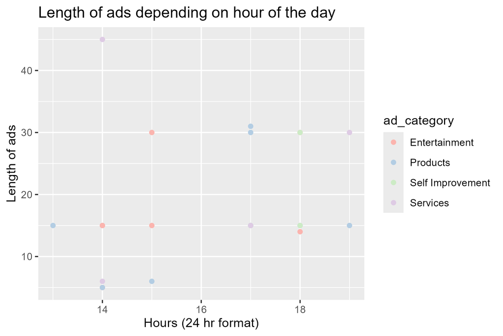

Scatter plot that shows ads that appear earlier in the day are more likely to be shorter

People may be more tired in the evening and really short ads might just be looked over due to fatigue throughout the day, hence longer ads are displayed at a later time so the viewer can process it.

## Does duration of ads change by category?

Seems that ads about services and products vary quite a lot. The most popular length for an ad is 15 seconds, with self improvement ads being the only type that doesn’t go under 15.

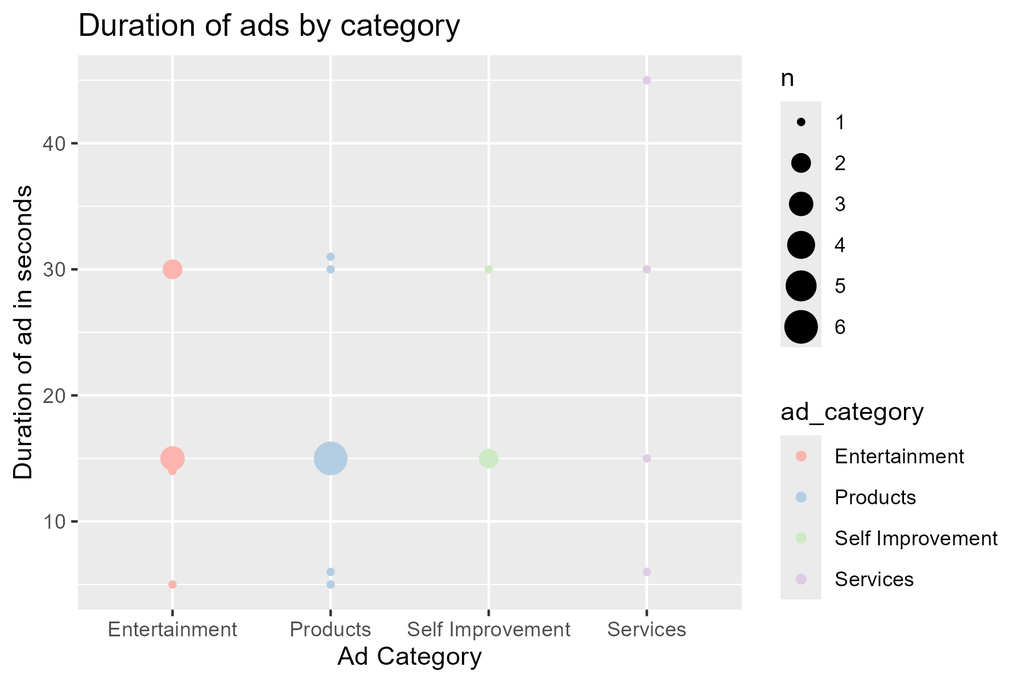

Bubble plot with duration of ad in seconds by ad category, with 15 seconds ads being the most frequent

Different types of things may need more or less time to reel somebody in, considering the differences in categories some stuff may require more thought put in to help engage the viewer

## What ads get skipped?

I tends to skip ads that are related to entertainment and watch through more of the ones that are trying to sell a product.

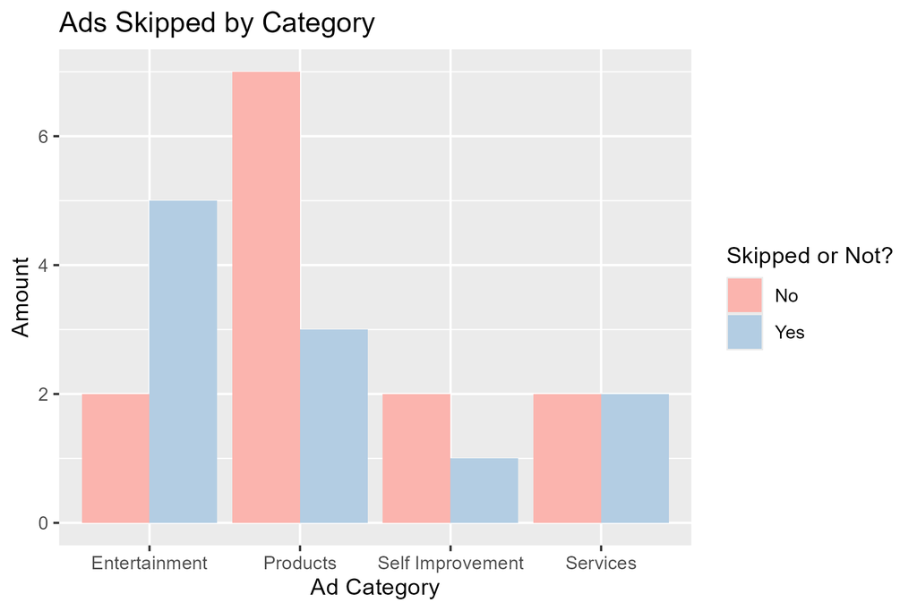

Bar graph separated by ad categories and shows how many of each get skipped or not, products are skipped the least and entertainment tends to get skipped

May be quite busy right now as ads about entertainment are skipped, but products aren’t as it could be useful/beneficial to me. Self improvement also has less skipped than skipped but the sample size is quite small.

## Conclusion

I am way more invested in products than the other categories and I think the ad algorithm is picking up on that, soon they may actually convince me to buy something.

[figure not shown]

Person sweating and stressing

(It would be very unwise for me to start impulsively buying things…)